# si544-day5-basic-regression

Matthew Garvin

10/4/2019

```r
library(tidyverse)
library(moderndive)
library(skimr)
library(gapminder)
```

## Load & Look

```r
evals_ch6 <- evals %>%
  select(ID, score, bty_avg, age)
```

`glimpse` can be helpful:

```r
glimpse(evals_ch6)
```

```
## Rows: 463
## Columns: 4
## $ ID      <int> 1, 2, 3, 4, 5, 6, 7, 8, 9, 10, 11, 12, 13, 14, 15, 16, 17, ...
## $ score   <dbl> 4.7, 4.1, 3.9, 4.8, 4.6, 4.3, 2.8, 4.1, 3.4, 4.5, 3.8, 4.5,...
## $ bty_avg <dbl> 5.000, 5.000, 5.000, 5.000, 3.000, 3.000, 3.000, 3.333, 3.3...
## $ age     <int> 36, 36, 36, 36, 59, 59, 59, 51, 51, 40, 40, 40, 40, 40, 40,...
```

Alternatively, you can draw a random sample of some values and look at what you get:

```r
evals_ch6 %>% sample_n(5)
```

```
## # A tibble: 5 x 4
##      ID score bty_avg   age
##   <int> <dbl>   <dbl> <int>
## 1    84   4.2    4.17    45
## 2   436   4.2    2       62
## 3   151   3.8    4.83    52
## 4   298   4.1    3.33    43
## 5   456   4.5    6.83    32
```

Now that you understand descriptive statistics and visualizations, let’s take a shortcut:

```r
evals_ch6 %>%
  select(score, bty_avg) %>%
  skim()
```

Data summary

| Name | Piped data |
| --- | --- |
| Number of rows | 463 |
| Number of columns | 2 |
| _______________________ |  |
| Column type frequency: |  |
| numeric | 2 |
| ________________________ |  |
| Group variables | None |

**Variable type: numeric**

| skim_variable | n_missing | complete_rate | mean | sd | p0 | p25 | p50 | p75 | p100 | hist |
| --- | --- | --- | --- | --- | --- | --- | --- | --- | --- | --- |
| score | 0 | 1 | 4.17 | 0.54 | 2.30 | 3.80 | 4.30 | 4.6 | 5.00 | ▁▁▅▇▇ |
| bty_avg | 0 | 1 | 4.42 | 1.53 | 1.67 | 3.17 | 4.33 | 5.5 | 8.17 | ▃▇▇▃▂ |

```r
evals_ch6 %>%
  get_correlation(formula = score ~ bty_avg)
```

```
## # A tibble: 1 x 1
##     cor
##   <dbl>
## 1 0.187
```

Equivalently:

```r
evals_ch6 %>%
  summarize(correlation = cor(score, bty_avg))
```

```
## # A tibble: 1 x 1
##   correlation
##         <dbl>
## 1       0.187
```

Visualization:

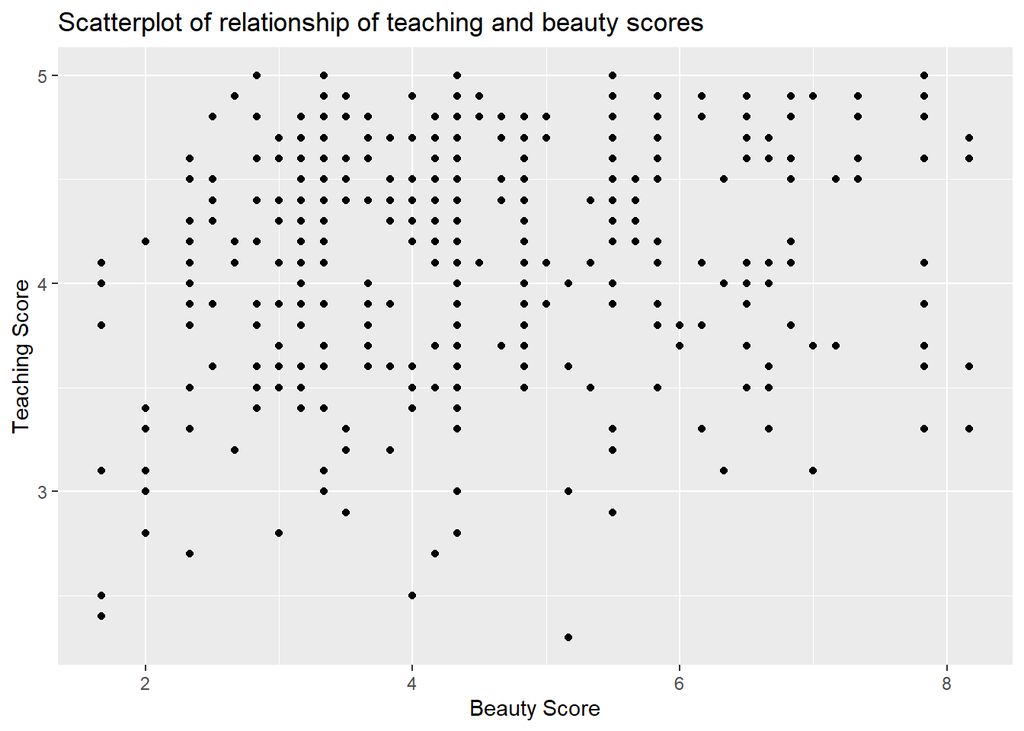

```r
ggplot(evals_ch6, aes(x = bty_avg, y = score)) +
  geom_point() +
  labs(x = "Beauty Score", y = "Teaching Score",
       title = "Scatterplot of relationship of teaching and beauty scores")
```

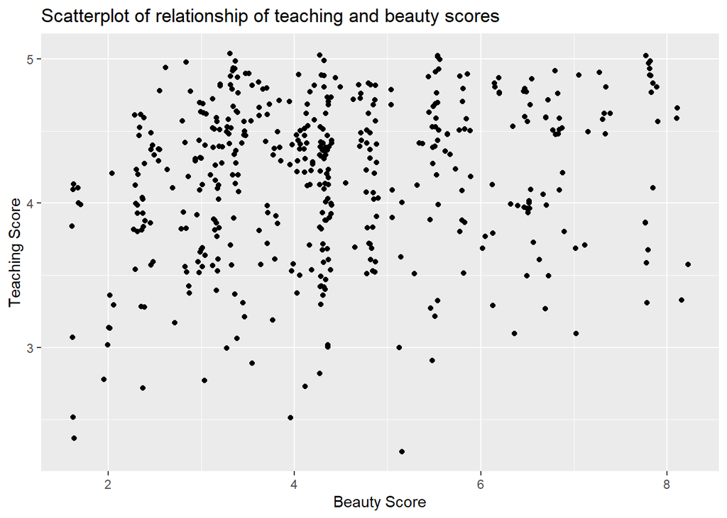

```r
ggplot(evals_ch6, aes(x = bty_avg, y = score)) +
  geom_jitter() +
  labs(x = "Beauty Score", y = "Teaching Score",
       title = "Scatterplot of relationship of teaching and beauty scores")
```

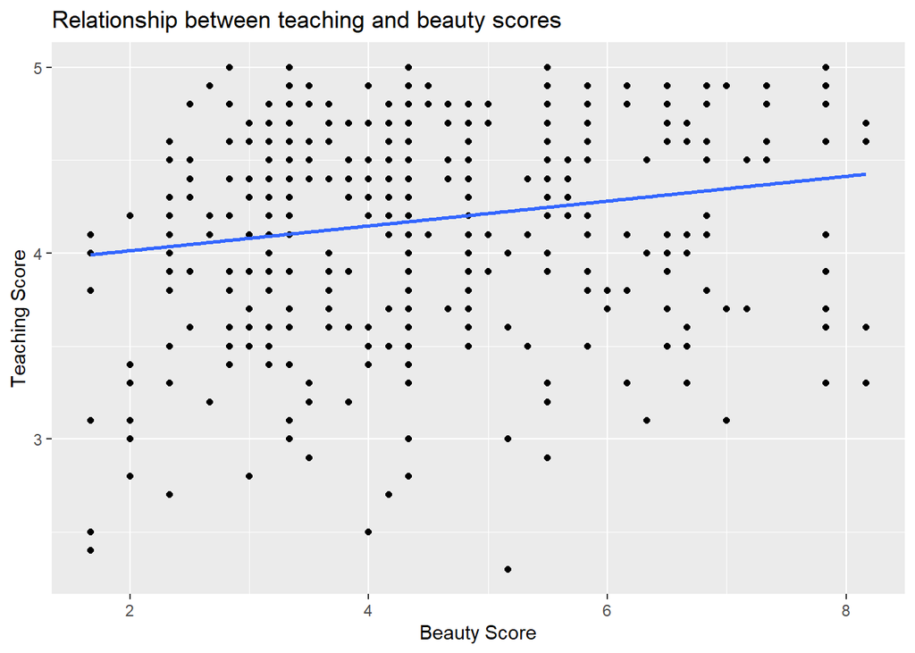

```r
ggplot(evals_ch6, aes(x = bty_avg, y = score)) +
  geom_point() +
  labs(x = "Beauty Score", y = "Teaching Score",
       title = "Relationship between teaching and beauty scores") +
  geom_smooth(method = "lm", se = FALSE)
```

### Learning Check 544.5.1

Repeat this for our handwriting data, looking at the relationship between dominant and non_dominant. The handwriting dataset is available via https://raw.githubusercontent.com/umsi-data-science/data/main/handwriting.csv (remember that you can give read_csv a URL).

First, load the data into a variable called `handwriting`.

```r
# INSERT YOUR R CODE HERE
handwriting <- read.csv("https://raw.githubusercontent.com/umsi-data-science/data/main/handwriting.csv")
```

1. Use glimpse() to get a “feel” for the handwriting data.

```r
# INSERT YOUR R CODE HERE
glimpse(handwriting)
```

```
## Rows: 79
## Columns: 3
## $ dominant    <dbl> 4.75, 7.00, 12.00, 7.00, 3.00, 4.10, 4.00, 5.00, 10.00,...
## $ nondominant <dbl> 10.43, 12.00, 20.00, 24.00, 10.00, 10.00, 13.00, 8.00, ...
## $ n_letters   <int> 10, 10, 10, 13, 11, 14, 13, 25, 16, 12, 13, 9, 11, 20, ...
```

2. Use skim() to generate summary statistics for dominant and non-dominant times.

```r
# INSERT YOUR R CODE HERE
handwriting %>%
  select(dominant, nondominant) %>%
  skim()
```

Data summary

| Name | Piped data |
| --- | --- |
| Number of rows | 79 |
| Number of columns | 2 |
| _______________________ |  |
| Column type frequency: |  |
| numeric | 2 |
| ________________________ |  |
| Group variables | None |

**Variable type: numeric**

| skim_variable | n_missing | complete_rate | mean | sd | p0 | p25 | p50 | p75 | p100 | hist |
| --- | --- | --- | --- | --- | --- | --- | --- | --- | --- | --- |
| dominant | 0 | 1 | 5.52 | 2.38 | 1 | 4.00 | 5 | 7 | 12 | ▃▇▃▂▁ |
| nondominant | 0 | 1 | 13.36 | 6.25 | 3 | 8.89 | 12 | 17 | 32 | ▅▇▅▁▁ |

3. Calculate the correlation coefficient for dominant and non-dominant times. What does that value tell you?

```r
# INSERT YOUR R CODE HERE
handwriting %>%
  summarise(corr_coef = cor(dominant, nondominant))
```

```
##   corr_coef
## 1 0.7053588
```

The correlation coefficient is .705

4. Create a scatterplot with non-dominant on the y (vertical) axis and dominant on the x (horizontal) axis. Use R to draw a line through the data to show the relationship between dominant and non-dominant times.

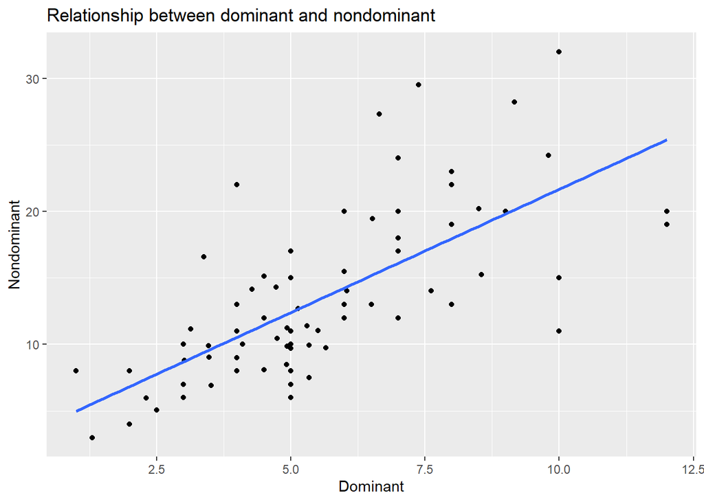

```r
# INSERT YOUR R CODE HERE
ggplot(handwriting, aes(dominant, nondominant)) +
  geom_point() +
    labs(x = "Dominant", y = "Nondominant",
       title = "Relationship between dominant and nondominant") +
  geom_smooth(method = "lm", se = FALSE)
```

## Simple Linear Regression

```r
# Fit regression model:
score_model <- lm(score ~ bty_avg, data = evals_ch6)
```

```r
# Get regression table:
get_regression_table(score_model)
```

```
## # A tibble: 2 x 7
##   term      estimate std_error statistic p_value lower_ci upper_ci
##   <chr>        <dbl>     <dbl>     <dbl>   <dbl>    <dbl>    <dbl>
## 1 intercept    3.88      0.076     51.0        0    3.73     4.03
## 2 bty_avg      0.067     0.016      4.09       0    0.035    0.099
```

```r
get_regression_summaries(score_model)
```

```
## # A tibble: 1 x 8
##   r_squared adj_r_squared   mse  rmse sigma statistic p_value    df
##       <dbl>         <dbl> <dbl> <dbl> <dbl>     <dbl>   <dbl> <dbl>
## 1     0.035         0.033 0.285 0.534 0.535      16.7       0     2
```

### Best fit

```r
regression_points <- get_regression_points(score_model)
regression_points
```

```
## # A tibble: 463 x 5
##       ID score bty_avg score_hat residual
##    <int> <dbl>   <dbl>     <dbl>    <dbl>
##  1     1   4.7    5         4.21    0.486
##  2     2   4.1    5         4.21   -0.114
##  3     3   3.9    5         4.21   -0.314
##  4     4   4.8    5         4.21    0.586
##  5     5   4.6    3         4.08    0.52
##  6     6   4.3    3         4.08    0.22
##  7     7   2.8    3         4.08   -1.28
##  8     8   4.1    3.33      4.10   -0.002
##  9     9   3.4    3.33      4.10   -0.702
## 10    10   4.5    3.17      4.09    0.409
## # ... with 453 more rows
```

Let’s calculate the sum of squared residuals using a pipeline:

```r
regression_points %>%
  mutate(squared_residuals = residual^2) %>%
  summarize(sum_of_squared_residuals = sum(squared_residuals))
```

```
## # A tibble: 1 x 1
##   sum_of_squared_residuals
##                      <dbl>
## 1                     132.
```

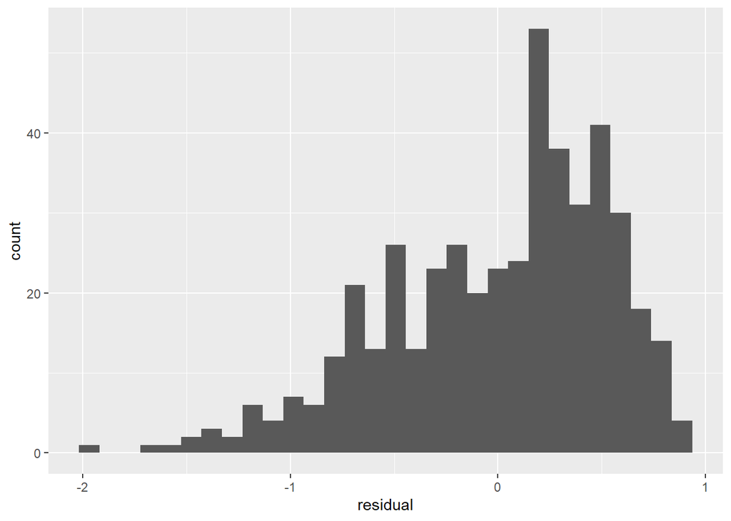

```r
ggplot(regression_points, mapping=aes(x=residual)) + geom_histogram()
```

### Learning Check 544.5.2

Repeat the above steps with the handwriting data from discussion section:

1. Create a linear model (using the lm() function) to model non-dominant time as the outcome variable and dominant time as the explanatory one.

```r
# INSERT YOUR R CODE HERE
handwriting_model <- lm(nondominant ~ dominant, data = handwriting)
```

2. Use get_regression_table() to get the coefficients for the regression model.

```r
# INSERT YOUR R CODE HERE
get_regression_table(handwriting_model)
```

```
## # A tibble: 2 x 7
##   term      estimate std_error statistic p_value lower_ci upper_ci
##   <chr>        <dbl>     <dbl>     <dbl>   <dbl>    <dbl>    <dbl>
## 1 intercept     3.13     1.27       2.45   0.016     0.59     5.67
## 2 dominant      1.85     0.212      8.73   0         1.43     2.28
```

3. What would the expected value of non-dominant time be for a name that took 6 seconds to write with one’s dominant hand? 3.129 + 1.853 * 6

We can predict 14.247 seconds to write your name with your nondominant hand.

4. Use get_regression_summaries() to get information about how “good” the model is. Comment on how much variance is explained by the model. What’s the average deviation from the predicted value?

```r
# INSERT YOUR CODE HERE
get_regression_summaries(handwriting_model)
```

```
## # A tibble: 1 x 8
##   r_squared adj_r_squared   mse  rmse sigma statistic p_value    df
##       <dbl>         <dbl> <dbl> <dbl> <dbl>     <dbl>   <dbl> <dbl>
## 1     0.498         0.491  19.4  4.40  4.46      76.2       0     2
```

5. Identify the two most extreme residual values. What do those values mean? Can you infer anything about the individuals with those values?

```r
# INSERT YOUR R CODE HERE
regression_points <- get_regression_points(handwriting_model) %>%
  summarise(max_residual = max(residual, na.rm = TRUE), min_residual = min(residual, na.rm = TRUE))
regression_points
```

```
## # A tibble: 1 x 2
##   max_residual min_residual
##          <dbl>        <dbl>
## 1         12.7        -10.7
```

```r
get_regression_points(handwriting_model) %>% arrange(desc(residual))
```

```
## # A tibble: 79 x 5
##       ID nondominant dominant nondominant_hat residual
##    <int>       <dbl>    <dbl>           <dbl>    <dbl>
##  1    67        29.5     7.38           16.8     12.7
##  2    40        27.3     6.65           15.5     11.9
##  3    12        22       4              10.5     11.5
##  4    59        32      10              21.7     10.3
##  5    79        28.2     9.17           20.1      8.11
##  6     4        24       7              16.1      7.90
##  7    31        16.6     3.38            9.39     7.19
##  8    35        20       6              14.2      5.75
##  9    17        23       8              18.0      5.04
## 10    56        17       5              12.4      4.61
## # ... with 69 more rows
```

```r
get_regression_points(handwriting_model) %>% arrange(residual)
```

```
## # A tibble: 79 x 5
##       ID nondominant dominant nondominant_hat residual
##    <int>       <dbl>    <dbl>           <dbl>    <dbl>
##  1     9       11       10               21.7   -10.7
##  2    76       15       10               21.7    -6.66
##  3    25        6        5               12.4    -6.40
##  4    66       19       12               25.4    -6.37
##  5    36        7.49     5.34            13.0    -5.54
##  6    34        7        5               12.4    -5.40
##  7    47        7        5               12.4    -5.40
##  8     3       20       12               25.4    -5.37
##  9    46       13        8               18.0    -4.96
## 10     8        8        5               12.4    -4.39
## # ... with 69 more rows
```